# Marketing Campaign EDA

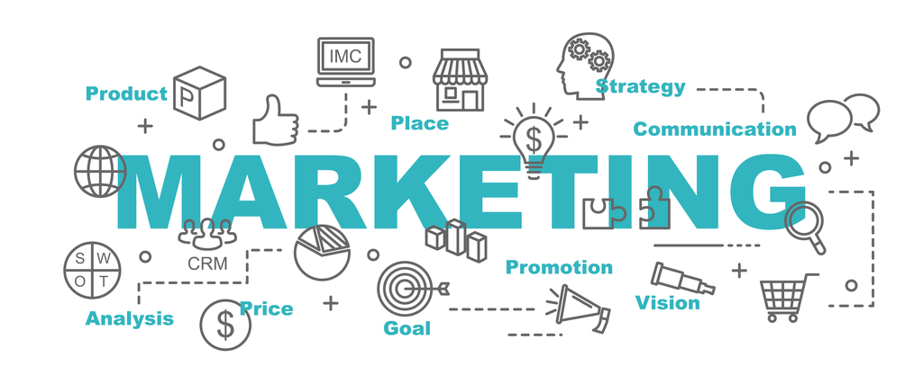

###### Importing libraries

```python
import pandas as pd
import numpy as np
import matplotlib.pyplot as plt
import seaborn as sns
import warnings
warnings.filterwarnings("ignore")
```

##### Taking a look at our dataset

```python
df=pd.read_csv('D:\data science analytics project\Marketing Project-20221115T174710Z-001\Marketing Project\marketing_data_cleaned.csv')
```

```python
pd.set_option('display.max_rows', None)
pd.set_option('display.max_columns', None)
```

```python
df.head()
```

|  | ID | Year_Birth | Education | Income | Kidhome | Teenhome | Dt_Customer | Recency | MntWines | MntFruits | MntMeatProducts | MntFishProducts | MntSweetProducts | MntGoldProds | NumDealsPurchases | NumWebPurchases | NumCatalogPurchases | NumStorePurchases | NumWebVisitsMonth | Marital_Status_new | AcceptedCmp1_new | AcceptedCmp2_new | AcceptedCmp3_new | AcceptedCmp4_new | AcceptedCmp5_new | AcceptedCmp6_new | Complain_new |
| --- | --- | --- | --- | --- | --- | --- | --- | --- | --- | --- | --- | --- | --- | --- | --- | --- | --- | --- | --- | --- | --- | --- | --- | --- | --- | --- | --- |
| 0 | 5524 | 1957 | Graduation | 58138 | 0 | 0 | 04-09-2012 | 58 | 635 | 88 | 546 | 172 | 88 | 88 | 3 | 8 | 10 | 4 | 7 | Single | No | No | No | No | No | Yes | No |
| 1 | 2174 | 1954 | Graduation | 46344 | 1 | 1 | 08-03-2014 | 38 | 11 | 1 | 6 | 2 | 1 | 6 | 2 | 1 | 1 | 2 | 5 | Single | No | No | No | No | No | No | No |
| 2 | 4141 | 1965 | Graduation | 71613 | 0 | 0 | 21-08-2013 | 26 | 426 | 49 | 127 | 111 | 21 | 42 | 1 | 8 | 2 | 10 | 4 | Married | No | No | No | No | No | No | No |
| 3 | 6182 | 1984 | Graduation | 26646 | 1 | 0 | 10-02-2014 | 26 | 11 | 4 | 20 | 10 | 3 | 5 | 2 | 2 | 0 | 4 | 6 | Married | No | No | No | No | No | No | No |
| 4 | 5324 | 1981 | PhD | 58293 | 1 | 0 | 19-01-2014 | 94 | 173 | 43 | 118 | 46 | 27 | 15 | 5 | 5 | 3 | 6 | 5 | Married | No | No | No | No | No | No | No |

Though data is already cleaned in sql but we will check for anomalies here too.

```python
df.info()
```

```
<class 'pandas.core.frame.DataFrame'>
RangeIndex: 2216 entries, 0 to 2215
Data columns (total 27 columns):
 #   Column               Non-Null Count  Dtype
---  ------               --------------  -----
 0   ID                   2216 non-null   int64
 1   Year_Birth           2216 non-null   int64
 2   Education            2216 non-null   object
 3   Income               2216 non-null   int64
 4   Kidhome              2216 non-null   int64
 5   Teenhome             2216 non-null   int64
 6   Dt_Customer          2216 non-null   object
 7   Recency              2216 non-null   int64
 8   MntWines             2216 non-null   int64
 9   MntFruits            2216 non-null   int64
```

[output cut: 19 more lines]

As we can see here Dt_Customer column is in object type we have to change it to date.

```python
# changing datatype of column
df.Dt_Customer = pd.to_datetime(df.Dt_Customer)
```

```python
df.Dt_Customer.info()
```

```
<class 'pandas.core.series.Series'>
RangeIndex: 2216 entries, 0 to 2215
Series name: Dt_Customer
Non-Null Count  Dtype
--------------  -----
2216 non-null   datetime64[ns]
dtypes: datetime64[ns](1)
memory usage: 17.4 KB
```

###### Checking shape of dataset , Searching for null values & duplicate values

```python
df.shape
```

```
(2216, 27)
```

```python
df.isnull().sum().sum()
```

```
0
```

```python
df.duplicated().sum()
```

```
0
```

1. No null values found
2. No duplicate values found

###### Checking descriptive statistics

```python
df.describe()
```

|  | ID | Year_Birth | Income | Kidhome | Teenhome | Recency | MntWines | MntFruits | MntMeatProducts | MntFishProducts | MntSweetProducts | MntGoldProds | NumDealsPurchases | NumWebPurchases | NumCatalogPurchases | NumStorePurchases | NumWebVisitsMonth |
| --- | --- | --- | --- | --- | --- | --- | --- | --- | --- | --- | --- | --- | --- | --- | --- | --- | --- |
| count | 2216.000000 | 2216.000000 | 2216.000000 | 2216.000000 | 2216.000000 | 2216.000000 | 2216.000000 | 2216.000000 | 2216.000000 | 2216.000000 | 2216.000000 | 2216.000000 | 2216.000000 | 2216.000000 | 2216.000000 | 2216.000000 | 2216.000000 |
| mean | 5588.353339 | 1968.820397 | 52247.251354 | 0.441787 | 0.505415 | 49.012635 | 305.091606 | 26.356047 | 166.995939 | 37.637635 | 27.028881 | 43.965253 | 2.323556 | 4.085289 | 2.671029 | 5.800993 | 5.319043 |
| std | 3249.376275 | 11.985554 | 25173.076661 | 0.536896 | 0.544181 | 28.948352 | 337.327920 | 39.793917 | 224.283273 | 54.752082 | 41.072046 | 51.815414 | 1.923716 | 2.740951 | 2.926734 | 3.250785 | 2.425359 |
| min | 0.000000 | 1893.000000 | 1730.000000 | 0.000000 | 0.000000 | 0.000000 | 0.000000 | 0.000000 | 0.000000 | 0.000000 | 0.000000 | 0.000000 | 0.000000 | 0.000000 | 0.000000 | 0.000000 | 0.000000 |
| 25% | 2814.750000 | 1959.000000 | 35303.000000 | 0.000000 | 0.000000 | 24.000000 | 24.000000 | 2.000000 | 16.000000 | 3.000000 | 1.000000 | 9.000000 | 1.000000 | 2.000000 | 0.000000 | 3.000000 | 3.000000 |
| 50% | 5458.500000 | 1970.000000 | 51381.500000 | 0.000000 | 0.000000 | 49.000000 | 174.500000 | 8.000000 | 68.000000 | 12.000000 | 8.000000 | 24.500000 | 2.000000 | 4.000000 | 2.000000 | 5.000000 | 6.000000 |
| 75% | 8421.750000 | 1977.000000 | 68522.000000 | 1.000000 | 1.000000 | 74.000000 | 505.000000 | 33.000000 | 232.250000 | 50.000000 | 33.000000 | 56.000000 | 3.000000 | 6.000000 | 4.000000 | 8.000000 | 7.000000 |
| max | 11191.000000 | 1996.000000 | 666666.000000 | 2.000000 | 2.000000 | 99.000000 | 1493.000000 | 199.000000 | 1725.000000 | 259.000000 | 262.000000 | 321.000000 | 15.000000 | 27.000000 | 28.000000 | 13.000000 | 20.000000 |

##### Checking income column

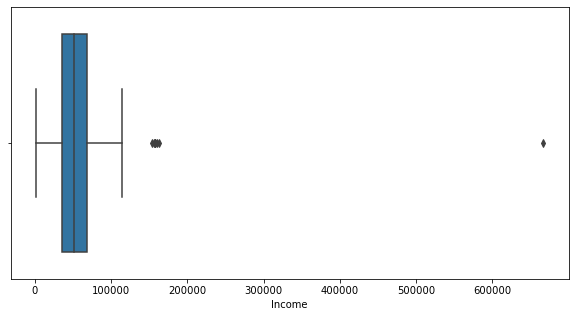

```python
plt.figure(figsize=(10,5))
sns.boxplot(df.Income)
plt.show()
```

Checking outliers in Income column

```python
q1=np.percentile(df.Income,25)
q3=np.percentile(df.Income,75)
iqr=q3-q1
df.Income[df.Income>(q3+1.5*iqr)]
```

```
153     157243
604     162397
642     153924
674     160803
1287    157733
1636    157146
2109    156924
2209    666666
Name: Income, dtype: int64
```

Index 2209 is not acceptable

```python
df.drop(index=2209,inplace=True)
```

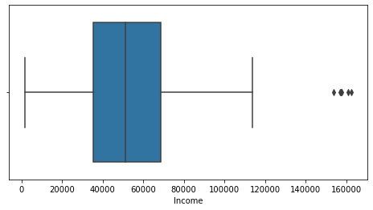

```python
plt.figure(figsize=(8,4))
sns.boxplot(df.Income)
plt.show()
```

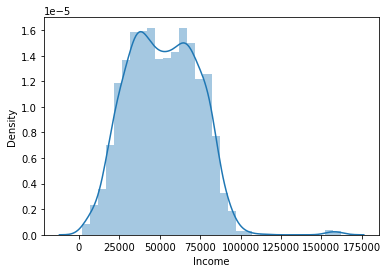

```python
sns.distplot(df.Income)
plt.show()
```

General distribution is between 40k to 60k

Creating bins:

Income: 0-35000 - Low

Income: >35000-70000 - Medium

Income: >70000 - High

```python
df['Income_level']=df.Income.apply(lambda x : 'Low' if x < 35000 else "Medium"
                                   if (x >= 35000 and x < 70000) else "High")
```

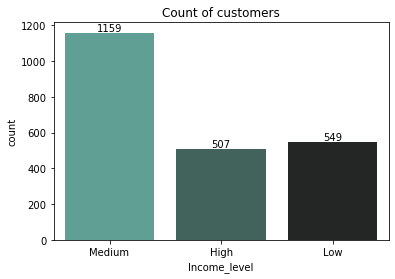

```python
cnt=sns.countplot(df.Income_level,palette="dark:#5A9_r")
plt.title('Count of customers')
for i in cnt.containers:
    cnt.bar_label(i)
plt.show()
```

Insight:

Most of the customers belong to medium Income level i.e. Income between 35000-70000

###### Now checking Kidhome and Teenhome (Teenhome+Kidhome=Minorhome)

```python
df['Minorhome']=df.Kidhome+df.Teenhome
```

Checking minor home on income level

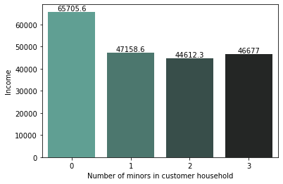

```python
ax=sns.barplot(df.Minorhome, df.Income,palette="dark:#5A9_r",ci=None)
plt.xlabel('Number of minors in customer household')
for i in ax.containers:
    ax.bar_label(i)
plt.show()
```

Insight: We can see that customers with no kids are more wealthy.

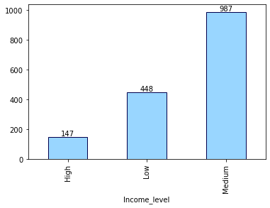

```python
ax=df[df.Minorhome!=0].groupby('Income_level').Minorhome.count().plot.bar(color='#99d6ff',edgecolor="#00004d")
for i in ax.containers:
    ax.bar_label(i)
plt.show()
```

Insight: High income people have very few children.

###### Checking relationship between Income and Recency to see whether high income people tend to visit more or not

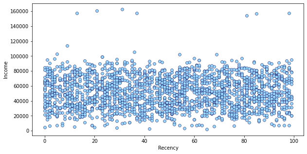

```python
plt.figure(figsize=(10,5))
sns.scatterplot(x = df.Recency, y = df.Income, ci = None,color='#99d6ff',edgecolor='#00004d')
plt.show()
```

```python
print(df['Income'].corr(df['Recency']))
```

```
0.006945070378962668
```

Insight:Income and recency are not related to each other in any way.

###### Creating total_spent column

Checking columns where Mnt(Amount spent) is there

```python
for i in df.columns:
    if 'Mnt' in i:
        print(i)
```

```
MntWines
MntFruits
MntMeatProducts
MntFishProducts
MntSweetProducts
MntGoldProds
```

```python
df['total_spent']=df.MntWines+df.MntFruits+df.MntMeatProducts+df.MntFishProducts+df.MntSweetProducts+df.MntGoldProds
```

Checking Relationship between total_spent and income columns.

```python
df.total_spent.corr(df.Income)
```

```
0.7926502833622057
```

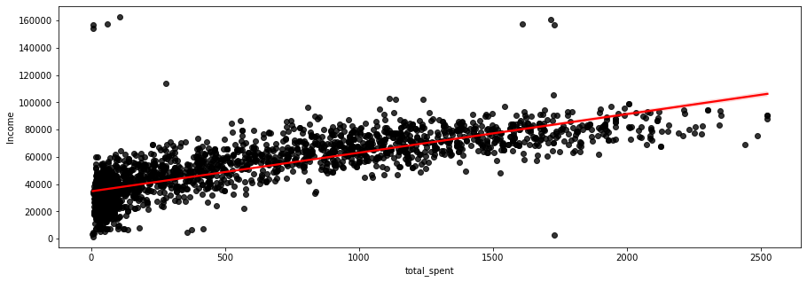

```python
plt.figure(figsize=(15,5))
sns.regplot(x=df.total_spent,y=df.Income,scatter_kws={'color':'black'},line_kws={'color':'red'})
plt.show()
```

There is a high positive correlation between total expenditure and income level.

Insight: People who earn more are likely to spend more.

###### Checking category wise money spent is linked to income or not.

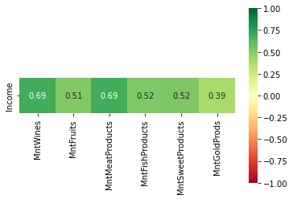

```python
sns.heatmap(df.corr().loc[['Income']][df[df.columns[df.columns.str.match('Mnt')]]
            .columns],annot=True,vmax=1,vmin=-1,cmap='RdYlGn',square=True)
plt.show()
```

Insight: Meat eating and wine drinking are related to income level.

###### Checking education column

```python
df.Education.unique()
```

```
array(['Graduation', 'PhD', 'Master', 'Basic', '2n Cycle'], dtype=object)
```

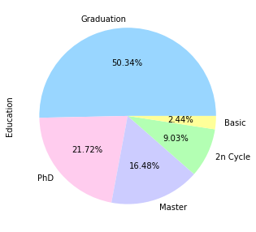

```python
plt.figure(figsize=(5,5))
df.Education.value_counts().plot(kind='pie',autopct="%.2f%%",colors = ["#99d6ff","#ffccee","#ccccff","#b3ffb3","#ffff99"])
plt.show()
```

###### Checking Education wise income level of customers.

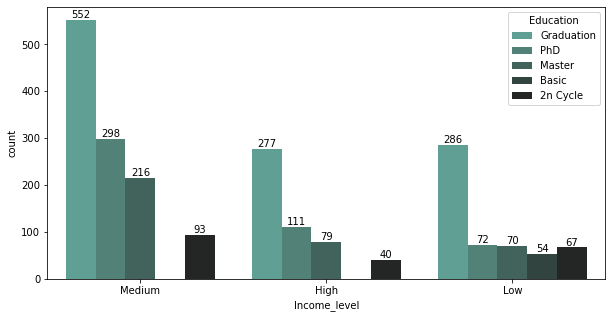

```python
plt.figure(figsize=(10,5))
ax=sns.countplot(x=df.Income_level,hue=df.Education,palette="dark:#5A9_r")
for i in ax.containers:
    ax.bar_label(i)
plt.show()
```

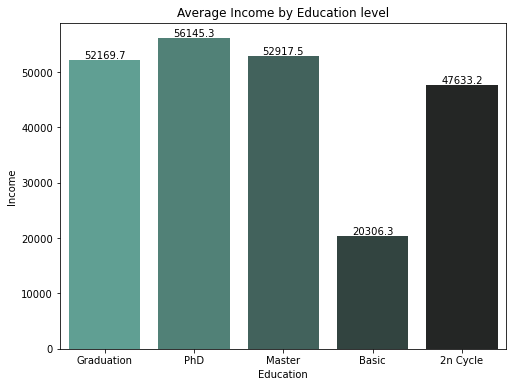

```python
plt.figure(figsize = (8,6))
ax = sns.barplot(df.Education, df.Income, ci = None,palette="dark:#5A9_r")
plt.title('Average Income by Education level')
for i in ax.containers :
    plt.bar_label(i)
```

Insight:

1. 50% customers have education level Graduation.
2. Basic education level stands out at low income level.
3. The low level of education is reflected in the income level.

###### Checking complain column

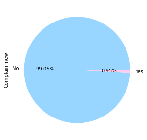

```python
plt.figure(figsize=(5,5))
df.Complain_new.value_counts().plot(kind='pie',autopct="%.2f%%", colors = ["#99d6ff","#ffccee"])
plt.show()
```

```python
df.groupby("Complain_new").Income.mean()
```

```
Complain_new
No     52034.254786
Yes    45242.285714
Name: Income, dtype: float64
```

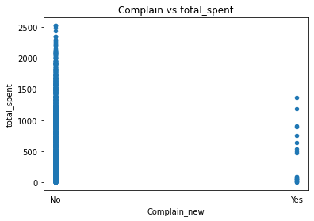

```python
df.plot(x='Complain_new', y='total_spent', kind='scatter')
plt.title("Complain vs total_spent")
plt.show()
```

Insight:

1. Customer satistfaction is very high.
2. Complainers have slightly lower income level.
3. Complainers spend less money.

###### Checking Marital Status Column

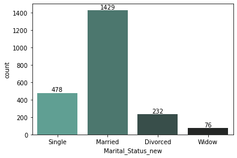

```python
ax=sns.countplot(df.Marital_Status_new,palette="dark:#5A9_r")
for i in ax.containers:
    plt.bar_label(i)
plt.show()
```

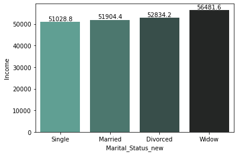

```python
ax=sns.barplot(x = df.Marital_Status_new, y = df.Income, ci = None,palette="dark:#5A9_r")
for i in ax.containers:
    plt.bar_label(i)
plt.show()
```

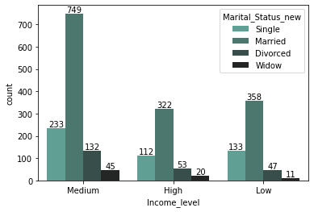

```python
ax = sns.countplot(x = df.Income_level, hue = df.Marital_Status_new,palette="dark:#5A9_r")
for i in ax.containers :
    plt.bar_label(i)
```

Insights:

1.Most of the customers are married.

2.Average income in all marital status are close.

3.In all income levels we have almost same ratio of people belonging to different marital statuses.

###### Checking NumDealsPurchases column

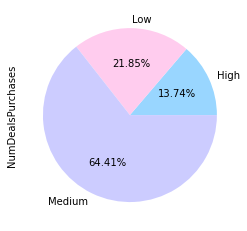

```python
(df.groupby("Income_level").NumDealsPurchases.sum() / df.NumDealsPurchases.sum()).plot(kind = "pie",subplots = True,autopct = "%.2f%%",colors = ["#99d6ff","#ffccee","#ccccff"])
plt.show()
```

Insight:

Discount purchase rates are higher for medium level income customers.

###### Checking NumCatalogPurchases column

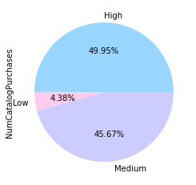

```python
(df.groupby("Income_level").NumCatalogPurchases.sum() / df.NumCatalogPurchases.sum()).plot(kind = "pie",subplots = True,autopct = "%.2f%%",colors = ["#99d6ff","#ffccee","#ccccff"])
plt.show()
```

Insights:

Catalog purchases are almost equally done by high and medium income level customers.

###### Checking NumWebPurchases column

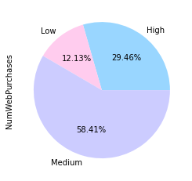

```python
(df.groupby("Income_level").NumWebPurchases.sum() / df.NumWebPurchases.sum()).plot(kind = "pie",subplots = True,autopct = "%.2f%%",colors = ["#99d6ff","#ffccee","#ccccff"])
plt.show()
```

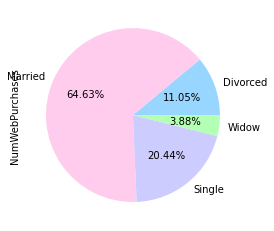

```python
(df.groupby("Marital_Status_new").NumWebPurchases.sum() / df.NumWebPurchases.sum()).plot(kind = "pie",subplots = True,autopct = "%.2f%%",colors = ["#99d6ff","#ffccee","#ccccff","#b3ffb3"])
plt.show()
```

Insights:

Maxiumum online purchases are done by Medium income level customer

Maximum Married customers purchased products online.

###### Checking NumWebVisits

```python
# Binning
df.loc[df['NumWebVisitsMonth'].between(0, 5, 'both'), 'webvisitbin'] = '0-5'
df.loc[df['NumWebVisitsMonth'].between(6, 10, 'right'), 'webvisitbin'] = '6-10'
df.loc[df['NumWebVisitsMonth'].between(11, 20, 'right'), 'webvisitbin'] = '11-more'
```

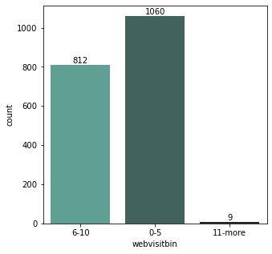

```python
plt.figure(figsize=(5,5))
ax=sns.countplot(df.webvisitbin,palette="dark:#5A9_r")
for i in ax.containers :
    plt.bar_label(i)
```

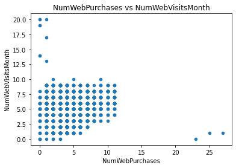

```python
df.plot(x='NumWebPurchases', y='NumWebVisitsMonth', kind='scatter')
plt.title("NumWebPurchases vs NumWebVisitsMonth")
plt.show()
```

###### Checking NumStorePurchases column

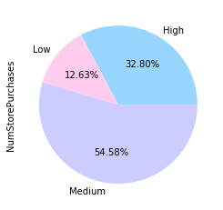

```python
(df.groupby("Income_level").NumStorePurchases.sum() / df.NumStorePurchases.sum()).plot(kind = "pie",subplots = True,autopct = "%.2f%%",colors = ["#99d6ff","#ffccee","#ccccff"])
plt.show()
```

###### Cheking MntWines column

```python
df.MntWines.sum()
```

```
676074
```

```python
np.round((df.MntWines.sum() / df.total_spent.sum() * 100),2)
```

```
50.26
```

Insight:

50% of spending went to wine

###### Checking MntFruits column

```python
df.MntFruits.sum()
```

```
58391
```

```python
np.round((df.MntFruits.sum() / df.total_spent.sum() * 100),2)
```

```
4.34
```

Insight:

4% of spending went to fruits.